# Relatório 07: Estimação Intervalar

Wagner Chaves Andrade

22/11/2024

# 1 Introdução

A estimação intervalar é uma técnica da estatística inferencial usada para estimar um parâmetro populacional, como uma média ou proporção, com um intervalo de valores em vez de apenas um ponto específico. O intervalo é construído de forma a incluir o parâmetro verdadeiro da população com uma determinada probabilidade, chamada de nível de confiança.

**Conceitos Básicos:**

- Intervalo de Confiança (IC): É o intervalo de valores no qual acreditamos que o parâmetro populacional verdadeiro se encontra. Ele é construído usando a média da amostra e uma margem de erro, baseada na variabilidade dos dados e no tamanho da amostra.
- Nível de Confiança: É a probabilidade de que o intervalo de confiança contenha o parâmetro verdadeiro. Por exemplo, um intervalo de confiança de 95% significa que, se repetirmos o experimento várias vezes, cerca de 95% dos intervalos construídos conterão o valor real do parâmetro populacional.
- Margem de Erro: Calculada com base no desvio padrão da amostra e no tamanho da amostra, é a quantidade que somamos e subtraímos da média amostral para definir o limite do intervalo.

**Exemplo Básico:**

Suponha que medimos a altura média de uma amostra de pessoas e encontramos uma média de 170 cm com um desvio padrão de 10 cm. Se usarmos um nível de confiança de 95%, podemos calcular um intervalo de confiança para estimar a média populacional com a fórmula do intervalo para uma média amostral.

A estimativa intervalar nos permite considerar a incerteza presente na amostra e obter uma estimativa mais confiável e prática do parâmetro populacional, sendo uma das ferramentas mais fundamentais na análise estatística.

# 2 Duas Distribuições Normais, Variâncias Conhecidas.

Neste relatório, consideraremos as inferências estatísticas para a diferença de médias $\mu_1-\mu_2$ de duas distribuições normais, em que as variâncias $\sigma_1^2$ e $\sigma_2^2$ são conhecidas

**Suposições para Inferência com Duas Amostras.**

- $X_{11},\, X_{12}\,,...,\,X_{1n}$ é uma amostra aleatória proveniente da população 1;
- $X_{21},\, X_{22}\,,...,\,X_{2n}$ é uma amostra aleatória proveniente da população 2;
- As duas populações representadas por $X_1$ e $X_2$ são independentes;
- Ambas as populações são normais.

# 3 Método da Quantidade Pivotal

O método da quantidade pivotal é uma técnica fundamental na inferência estatística, usada para construir intervalos de confiança. Ele explora uma estatística chamada de quantidade pivotal, que é uma função das variáveis amostrais e de um ou mais parâmetros desconhecidos e que possui uma distribuição conhecida. Isso torna o método extremamente útil para criar estimativas de intervalo, especialmente quando a distribuição exata dos estimadores é difícil de determinar.

**Definição de uma Quantidade Pivotal**

Uma quantidade pivotal, $Q(X;\theta)$, é uma função de uma amostra $X$ e do parâmetro $\theta$, e sua distribuição é independente do valor de $\theta$. Ou seja, se conhecemos a distribuíção de $Q(X;\theta)$, podemos usá-la para fazer inferências sobre $\theta$ sem depender do valor específico de $\theta$.

**Exemplo: Intervalo de Confiança para a Média com Variância Conhecida**

Considerando uma amostra $X_1,X_2,..., X_n$ extraída de uma distribuição normal $N(\mu;\sigma^2)$ com variância $\sigma^2$ conhecida, podemos definir a quantidade pivotal como:

$$Z\;=\;\frac{\bar
X-\mu}{\frac{\sigma}{\sqrt n}}$$

onde $\bar{X}$ é a média amostral e $Z\;\sim\;N\,(0,1)$ pela padronização da variável normal.

A partir dessa quantidade pivotal, podemos estabelecer um intervalo de confiança para $\mu$:

$$P\left(-\;z_{\frac{\alpha}{2}\;}\;\leq\;\frac{\bar
X-\mu}{\frac{\sigma}{\sqrt n}}\;\leq\;z_{\frac{\alpha}{2}}
\right)\;=\;1\;-\;\alpha$$

Reorganizando, obtemos:

$$P\left(\bar
X-\;z_{\frac{\alpha}{2}\;}\frac{\sigma}{\sqrt n}\;\leq\;\mu\leq\;\bar
X\;+\;z_{\frac{\alpha}{2}}\;\frac{\sigma}{\sqrt n}
\right)\;=\;1\;-\;\alpha$$

Esse é um intervalo de confiança $1 - \alpha$, para o parêmetro $\mu$, utilizando a quantidade pivotal $Z$.

**Vantagens do Método da Quantidade Pivotal**

- Generalizabilidade: O método é aplicável para diversos tipos de distribuições e amostras.
- Construção de Intervalos de Confiança: Facilita a criação de intervalos de confiança precisos para diferentes parâmetros.
- Independência do Parâmetro: Como a distribuição de uma quantidade pivotal não depende do parâmetro desconhecido, é mais fácil trabalhar com ela do que com estatísticas cuja distribuição varia com o parâmetro.

**Desafios e Limitações**

Para aplicar o método de quantidade pivotal, precisamos de pivôs cujas distribuições sejam conhecidas e independentes dos parâmetros. Em casos complexos, como amostras pequenas ou distribuições desconhecidas, a construção de quantidades pivots pode ser impraticável.

## 3.1 Definição do Problema

Suponha que um fabricante de medicamentos deseja comparar a eficácia de dois novos medicamentos, $A$ e $B$, para tratar uma mesma doença. A eficácia de cada medicamento é medida pela redução média na pressão arterial de pacientes após um mês de uso.

O fabricante conduziu um experimento em que aplicou o medicamento $A$ em um grupo de 40 pacientes e o medicamento $B$ em outro grupo independente de 35 pacientes. A eficácia de cada medicamento (ou seja, a redução média na pressão arterial) é suposta ser normalmente distribuída. A variância das reduções da pressão arterial é conhecida para cada grupo:

- Para o medicamento $A$, a variância é $\sigma^2\;=\;20.$
- Para o medicamento $B$, a variância é $\sigma^2\;=\;25.$

As médias amostrais das reduções na pressão arterial observadas foram:

- Para o medicamento $A$, $\bar X_1\;=\;15.$
- Para o medicamento $B$, $\bar X_2\;=\;10.$

O objetivo é construir um intervalo de confiança para a diferença nas médias populacionais de redução na pressão arterial dos medicamentos $A$ e $B$ com um nível de confiança de 95%.

**SOLUÇÃO**

Para determinar o intervalo de confiança para a diferença $\mu_1-\mu_2$ entre as médias populacionais de eficácia dos medicamentos, usamos a fórmula para um intervalo de confiança com variâncias conhecidas:

$$(\bar X_1\,-\,\bar
X_2)\;\pm\;z_{\frac{\alpha}{2}}\,\sqrt
{\frac{\sigma_1^2}{n_1}\,+\,\frac{\sigma_2^2}{n_2}}$$

onde:

- $z_{\frac{\alpha}{2}}$ é o valor critico da distribuição normal padrão para o nível de confiança desejado (para 95%, $z_{\frac{\alpha}{2}}\approx\, 1,96$).
- $n_1\;=\;40$ e $n_2\;=\;35$ são os tamanhos das amostras para os medicamentos $A$ e $B$, respectivamente.
- Diferença entre as médias:

$$\bar X_1\,-\,\bar X_2\;=\;15 - 10 = 5$$

- Vaor crítico de (Z) para 95% de confiança:

Para um nível de confiança de 95%, o valor crítico Z correspondente é aproximadamente 1,96 (que pode ser obtido de uma tabela de distribuição normal ou pela função qnorm no R).

- Erro padrão da diferença entre as médias:

$$\sqrt
{\frac{\sigma_1^2}{n_1}\,+\,\frac{\sigma_2^2}{n_2}} = \sqrt
{\frac{20}{40}\,+\,\frac{25}{35}}\;=\;\sqrt{0,5\,+\,0,7143}\;\approx\;1,102$$

- Intervalo de confiança:

O intervalo de confiança para a diferença entre as médias populacionais $(\mu_1-\mu_2)$ é dado por:

$$(\bar X_1\,-\,\bar X_2)\,\pm\,Z\,\times
Erro\;Padrão$$

$$IC\;=\;5\,\pm\,1,96\,\times\,1,102$$

$$IC\;=\;5\,\pm\,2,16$$

Portanto, o intervalo de confiança de 95% para a diferença entre as médias populacionais de redução na pressão arterial dos medicamentos A e B é aproximadamente:

$$[2,84\,;\,7,16]$$

Com 95% de confiança, podemos afirmar que a diferença entre as médias populacionais de redução na pressão arterial para os medicamentos A e B está entre aproximadamente 2,84 e 7,16.

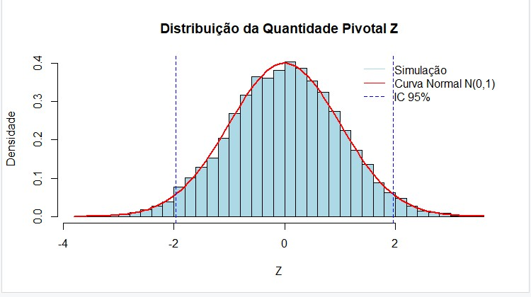

# 4 Aplicação do I.C. a um conjunto de dados

Considere duas máquinas que produzem peças, dos quais estamos avaliando a resistência à tensão dessas máquinas (MPa). Retirou-se uma amostra de 8 peças de cada máquina, e obtendo as seguintes resistências:

Máquina 1: $\{ 161, 147, 162, 161, 154, 136, 142, 147\}$

Máquina 1: $\{ 140, 162, 147, 133, 130, 137, 137, 136\}$

Considere que a resistência à tensão apresenta distribuição normal e que as variâncias populacionais são conhecidas para os dados obtidos pelas duas máquinas, porém iguais,encontre um estimador intervalar para a diferença das médias dos dois grupos, com um nível de confiança de 99% de probabilidade.

## 4.1 Apresentação analítica do resulatado

- **Tamanho das amostras:** $n_1\,=\,n_2\,=\,8$
- **Médias amostrais:**

$$\bar
X_1\;=\;\frac{161\,+\,147\,+\,162\,+\,161\,+\,154\,+\,136\,+\,142\,+\,147}{8}\;=\;151,25$$

$$\bar
X_2\;=\;\frac{140\,+\,162\,+\,147\,+\,133\,+\,130\,+\,137\,+\,137\,+\,136}{8}\;=\;140,25$$

- **Diferença das médias:**

$$\bar X_1\;-\;\bar
X_2\;=\;151,25-140,24\;=\;11$$

- **Variâncias amostrais:**

$$s_1^2\;=\;\frac{\sum_1^n\,(X_{1i}-\bar
X_1)^2}{n-1}$$

$$s_2^2\;=\;\frac{\sum_2^n\,(X_{2i}-\bar
X_2)^2}{n-1}$$

Substituindo o respectivos valores, encontramos:

- **Variância combinada:**

$$\sqrt
{s_p^2\left(\frac{1}{n_1}+\frac{1}{n_2}\right)}\;=\;\sqrt {98,93
\times\left(\frac{1}{8}+\frac{1}{8}\right)}\;=\;4,974$$

- **Intervalo de Confiança:**

$$IC\;=\;(\bar X_1\,-\,\bar
X_2)\,\pm\,t_{\frac{\alpha}{2}}\times\;Erro\;padrão$$

$$IC\;=\;11\,\pm\,2,977\,\times4,974$$

## 4.2 Apresentação e solução usando o RStudio.

[figure not shown]